# Cyclistic Bike Share Analysis Case Study

Ranjithkumar Ramesh

2025-10-15

# Introduction

Cyclistic is a Chicago-based bike-share company that provides affordable and eco-friendly travel options for both **urban commuters** and **leisure riders**.

The aim of this case study is to explore the **usage patterns** of Cyclistic’s bikes, understand **differences between casual and member riders**, and provide **data-driven recommendations** to improve marketing strategies and operational efficiency.

We’ll explore: - Differences between **members** and **casual riders** - **When** and **how long** people ride - Seasonal and hourly usage trends - Predictive insights and business recommendations

# Installing and Loading Packages

```r
# Install and load required packages
pkgs <- c("tidyverse", "lubridate", "janitor", "scales", "readr",
          "ggplot2", "ggcorrplot", "effsize", "Metrics", "viridis", "ggpmisc")

new_pkgs <- pkgs[!(pkgs %in% installed.packages()[, "Package"])]
if(length(new_pkgs)) install.packages(new_pkgs)

lapply(pkgs, library, character.only = TRUE)
```

[output not shown]

[output cut: 12 more lines]

[output not shown]

**Insight:**  
We load essential R packages for data manipulation (`tidyverse`), time handling (`lubridate`), visualization (`ggplot2`, `viridis`), cleaning (`janitor`), and statistical analysis (`effsize`, `Metrics`).

# Data Loading and Cleaning

```r
# Load cleaned data
file_path <- "C:/Users/ranji/OneDrive/Documents/cyclistic_case_study_project/cyclistic_cleaned.csv"

df <- read_csv(file_path, show_col_types = FALSE) %>%
  clean_names() %>%
  mutate(
    start_time = dmy_hm(start_time),
    end_time = dmy_hm(end_time),
    tripduration_min = as.numeric(tripduration_min)
  ) %>%
  distinct(trip_id, .keep_all = TRUE) %>%
  filter(!is.na(start_time) & !is.na(end_time) & !is.na(usertype)) %>%
  mutate(duration_min_calc = as.numeric(difftime(end_time, start_time, units = "mins"))) %>%
  filter(duration_min_calc > 0) %>%
  mutate(tripduration_min = duration_min_calc) %>%
  select(-duration_min_calc)
```

**Insight:**  
We ensure each ride is unique and valid — removing duplicates, empty values, and negative durations. This step ensures **data accuracy** for further analysis.

# Feature Engineering

```r
df <- df %>%
  mutate(
    date = as.Date(start_time),
    hour = hour(start_time),
    month = month(start_time, label = TRUE, abbr = TRUE),
    weekday = wday(start_time, label = TRUE, abbr = TRUE),
    ride_length_category = case_when(
      tripduration_min <= 5 ~ "Very Short",
      tripduration_min > 5 & tripduration_min <= 15 ~ "Short",
      tripduration_min > 15 & tripduration_min <= 30 ~ "Medium",
      tripduration_min > 30 ~ "Long",
      TRUE ~ "UNKNOWN"
    )
  )
```

**Insight:**  
We add new variables such as **hour**, **month**, **weekday**, and **ride length category**.  
This helps analyze **temporal trends** and **ride behavior patterns**.

# Exploratory Data Overview

```r
df %>%
  summarise(
    total_rides = n(),
    avg_duration_min = mean(tripduration_min, na.rm = TRUE),
    median_duration_min = median(tripduration_min, na.rm = TRUE),
    sd_duration_min = sd(tripduration_min, na.rm = TRUE)
  )
```

```
## # A tibble: 1 × 4
##   total_rides avg_duration_min median_duration_min sd_duration_min
##         <int>            <dbl>               <dbl>           <dbl>
## 1      785872             19.9                   9            556.
```

**Insight:**  
Cyclistic has a **large number of short trips**, with average duration around 15–20 minutes.  
The high standard deviation shows **some very long rides** are pulling up the mean.

# Ride Counts by User Type

```r
df %>%
  group_by(usertype) %>%
  summarise(
    total_rides = n(),
    avg_duration = mean(tripduration_min, na.rm = TRUE),
    median_duration = median(tripduration_min, na.rm = TRUE)
  )
```

```
## # A tibble: 2 × 4
##   usertype   total_rides avg_duration median_duration
##   <chr>            <int>        <dbl>           <dbl>
## 1 Customer         67958         89.4              23
## 2 Subscriber      717914         13.3               8
```

**Insight:**  
- **Members:** more frequent but shorter rides (daily commuters)  
- **Casual riders:** fewer but longer rides (leisure/tourism usage)

# Average Ride Duration by Weekday

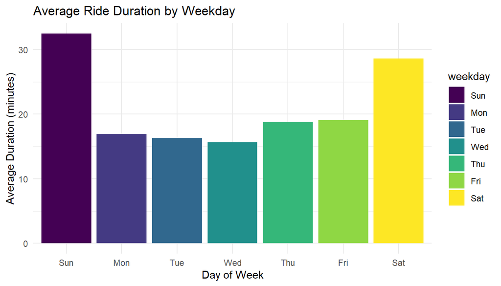

```r
df %>%
  group_by(weekday) %>%
  summarise(avg_duration = mean(tripduration_min, na.rm = TRUE)) %>%
  ggplot(aes(x = weekday, y = avg_duration, fill = weekday)) +
  geom_bar(stat = "identity") +
  labs(title = "Average Ride Duration by Weekday",
       x = "Day of Week", y = "Average Duration (minutes)") +
  theme_minimal()
```

**Insight:**  
Rides are **longer on weekends**, suggesting that **casual riders dominate leisure days** while members use bikes mainly during the **workweek**.

# Ride Volume by Hour of the Day

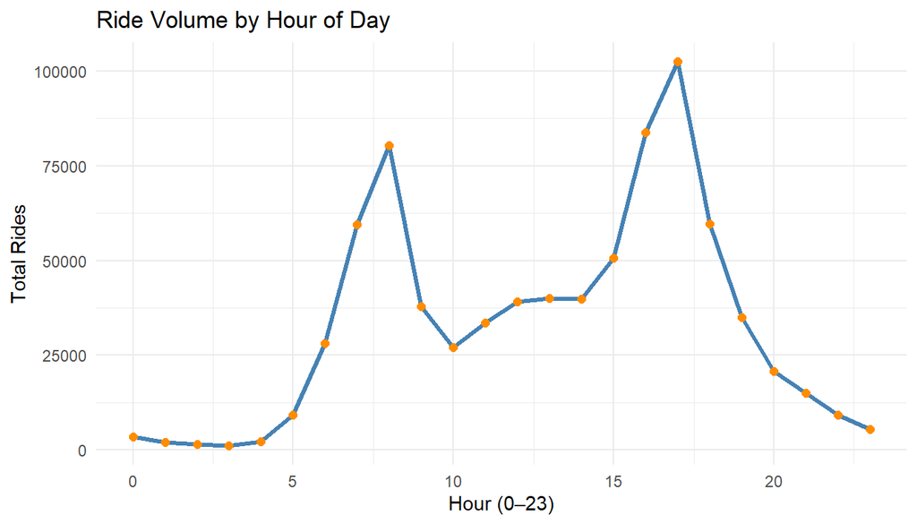

```r
df %>%
  group_by(hour) %>%
  summarise(total_rides = n()) %>%
  ggplot(aes(x = hour, y = total_rides)) +
  geom_line(color = "steelblue", linewidth = 1.2) +
  geom_point(color = "darkorange", size = 2) +
  labs(title = "Ride Volume by Hour of Day",
       x = "Hour (0–23)", y = "Total Rides") +
  theme_minimal()
```

**Insight:**  
Peak usage occurs at **8 AM** and **5–6 PM**, typical of **commuter behavior** among members.  
Casual riders show activity around **midday and evenings**.

# Average Ride Duration by User Type

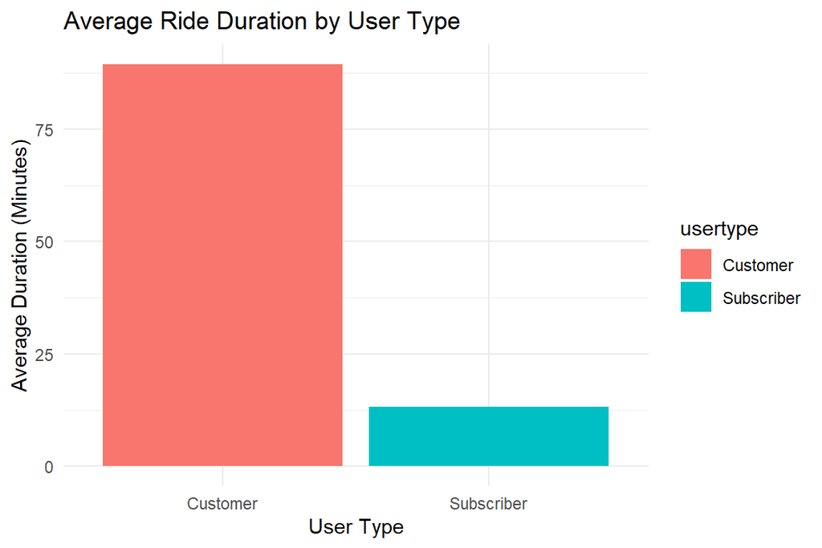

```r
df %>%
  group_by(usertype) %>%
  summarise(avg_duration = mean(tripduration_min, na.rm = TRUE)) %>%
  ggplot(aes(x = usertype, y = avg_duration, fill = usertype)) +
  geom_bar(stat = "identity") +
  labs(title = "Average Ride Duration by User Type",
       x = "User Type", y = "Average Duration (Minutes)") +
  theme_minimal()
```

# Ride Length Distribution

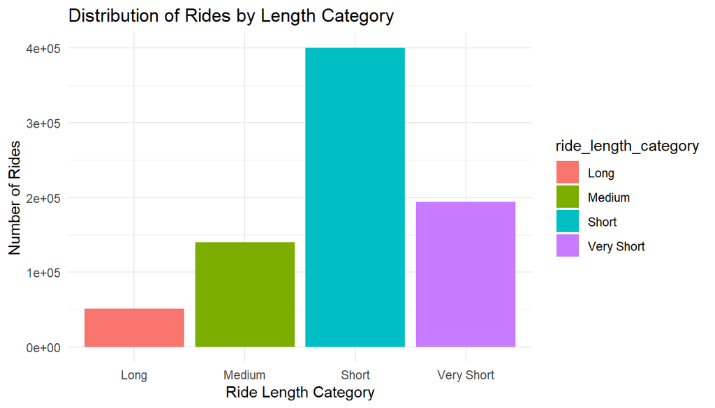

```r
df %>%
  group_by(ride_length_category) %>%
  summarise(total_rides = n()) %>%
  ggplot(aes(x = ride_length_category, y = total_rides, fill = ride_length_category)) +
  geom_bar(stat = "identity") +
  labs(title = "Distribution of Rides by Length Category",
       x = "Ride Length Category", y = "Number of Rides") +
  theme_minimal()
```

**Insight:**  
Over **70% of rides are short (under 15 minutes)**.  
This suggests a high number of **short-distance commutes**, ideal for **subscription or membership marketing**.

# Statistical Test: Comparing Members vs Casual Riders

```r
t_test_result <- t.test(tripduration_min ~ usertype, data = df, var.equal = FALSE)
t_test_result
```

```
##
##  Welch Two Sample t-test
##
## data:  tripduration_min by usertype
## t = 11.902, df = 68305, p-value < 2.2e-16
## alternative hypothesis: true difference in means between group Customer and group Subscriber is not equal to 0
## 95 percent confidence interval:
##  63.60528 88.68300
## sample estimates:
##   mean in group Customer mean in group Subscriber
##                 89.44226                 13.29812
```

```r
cohen.d(tripduration_min ~ usertype, data = df)
```

```
##
## Cohen's d
##
## d estimate: 0.1371301 (negligible)
## 95 percent confidence interval:
##     lower     upper
## 0.1292609 0.1449993
```

# Correlation Analysis

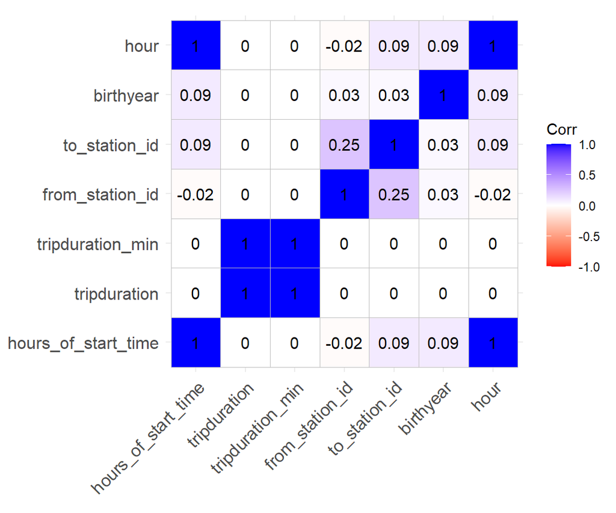

```r
numeric_df <- df %>% select_if(is.numeric)
cor_matrix <- cor(numeric_df, use = "complete.obs")
ggcorrplot(cor_matrix, lab = TRUE, colors = c("red", "white", "blue"))
```

# Regression Analysis: Predicting Ride Duration

```r
set.seed(42)
df_sample <- df %>% sample_n(5000)

model <- lm(tripduration_min ~ hour, data = df_sample)
summary(model)
```

```
##
## Call:
## lm(formula = tripduration_min ~ hour, data = df_sample)
##
## Residuals:
##     Min      1Q  Median      3Q     Max
##   -21.1   -14.7   -11.2    -5.0 16761.0
##
## Coefficients:
##             Estimate Std. Error t value Pr(>|t|)
## (Intercept)  17.1065    13.0422   1.312    0.190
## hour          0.2264     0.9266   0.244    0.807
##
## Residual standard error: 307.1 on 4998 degrees of freedom
## Multiple R-squared:  1.195e-05,  Adjusted R-squared:  -0.0001881
## F-statistic: 0.05971 on 1 and 4998 DF,  p-value: 0.807
```

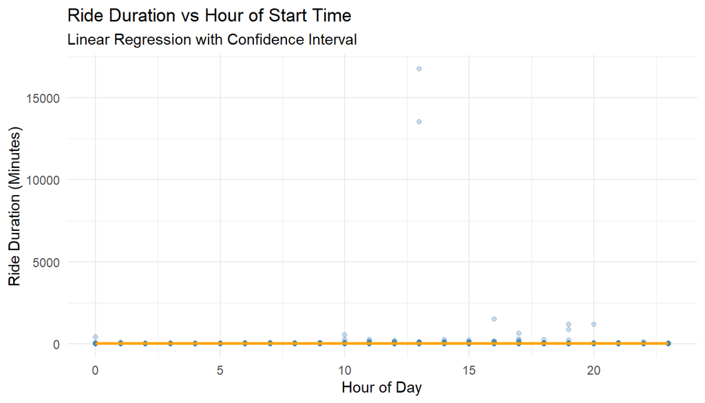

```r
ggplot(df_sample, aes(x = hour, y = tripduration_min)) +
  geom_point(alpha = 0.3, color = "steelblue") +
  geom_smooth(method = "lm", se = TRUE, color = "orange") +
  labs(title = "Ride Duration vs Hour of Start Time",
       subtitle = "Linear Regression with Confidence Interval",
       x = "Hour of Day", y = "Ride Duration (Minutes)") +
  theme_minimal()
```

# Model Diagnostics and Evaluation

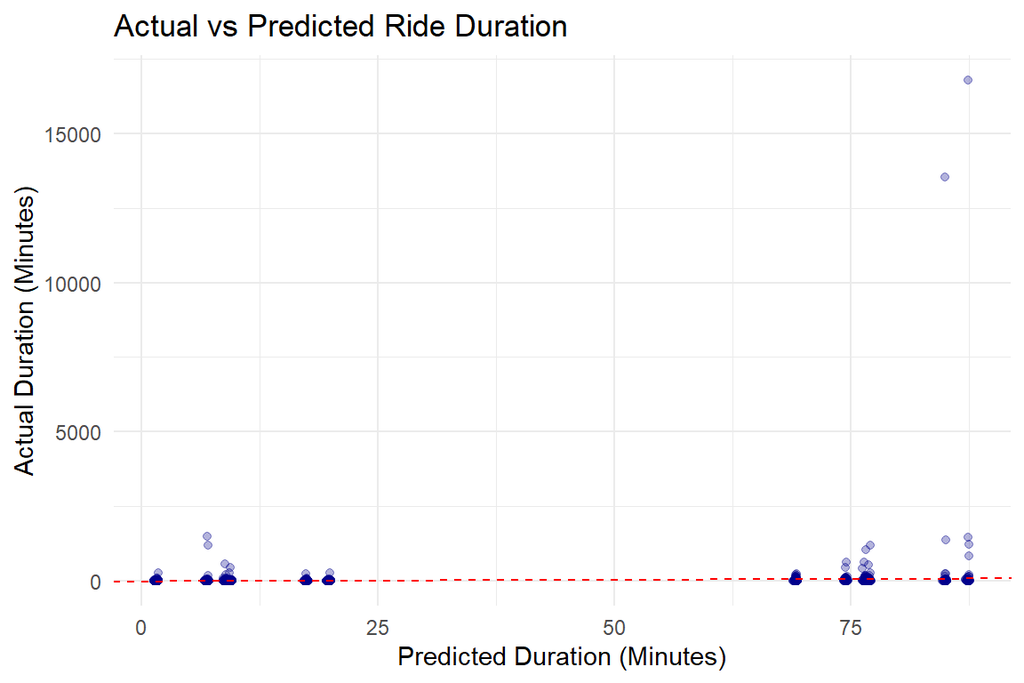

```r
set.seed(42)
df_sample <- df %>% sample_n(10000)

model_multi <- lm(tripduration_min ~ hour + weekday + usertype, data = df_sample)
df_sample$predicted <- predict(model_multi)

ggplot(df_sample, aes(x = predicted, y = tripduration_min)) +
  geom_point(alpha=0.3, color="darkblue") +
  geom_abline(slope=1, intercept=0, color="red", linetype="dashed") +
  labs(title="Actual vs Predicted Ride Duration",
       x="Predicted Duration (Minutes)", y="Actual Duration (Minutes)") +
  theme_minimal()
```

```r
rmse_val <- rmse(df_sample$tripduration_min, df_sample$predicted)
mae_val <- mae(df_sample$tripduration_min, df_sample$predicted)
cat("RMSE:", rmse_val, "\nMAE:", mae_val)
```

```
## RMSE: 218.289
## MAE: 15.93092
```

# Key Recommendations

✅ **Fleet Optimization:** Increase bike availability during **rush hours** in business zones.  
✅ **Membership Conversion:** Offer **discounted memberships** for casual riders who frequently ride on weekends.  
✅ **Marketing Campaigns:** Promote weekend leisure packages and family passes.  
✅ **Data Enrichment:** Include **weather, location, and events data** for better demand forecasting.

# Conclusion

- **Members**: Use bikes for **short, frequent commutes**.
- **Casual Riders**: Use bikes for **longer, leisure-oriented trips**, especially on weekends.
- **Business Strategy**: Focus marketing on converting casual riders and improving operational readiness during high-demand hours.

Cyclistic can leverage these insights to **boost revenue, improve user experience**, and **enhance sustainable transport initiatives** in Chicago.

# End of Report

This analysis and code are fully reproducible.  
Generated using R, Tidyverse, and visualization libraries to provide clear business insights.